# Session 2 - Overview

## Recap

Project related

- Presentation of the project
- Explanation of the project's dataset
- Minimal example for the project

With an example dataset: Some aspects to consider when working with data / on your project

- data preprocessing
- handling of missing values
- outliers and extreme Values
- some univeriate and bivariate descriptive analysis and how they could help you
- why logistic regression and not linear regression
- how to include categorical variables in a logistic regression
- gini and roc-auc (receiver operating characteristic - area under the curve)

## Today' s Agenda

- Some more aspects to consider when working with data / on your project
- Q&A with Christoph Meister (BTV's RMF) around 14:15
- Working on your project

# Session 2 - Let's code and analyze

# Settings

```python
# Loading packages
from src import fileloader
from src import helpers

import pandas as pd
import sklearn as sk
import numpy as np
import statsmodels.api as sm
import statsmodels.formula.api as smf
from matplotlib import pyplot as plt

from sklearn import tree
from sklearn import metrics
from sklearn.model_selection import KFold

from tqdm import tqdm
```

```python
# User input
filepath = 'data/example_dataset_full.csv'
```

# Load and preprocess data

```python
dataset = fileloader.get_data(file_path = filepath, frac_train = 0.8, random_state=1)

for k, df in dataset.items():
    dataset[k] = fileloader.preprocess_data(df)
```

**What do we already know about the data?**

- ...

**Reminder** In contrast to our example dataset, your dataset is small on the one hand and messy on the other hand.

# Feature Engineering

What is feature engineering?

Feature engineering is the process of using domain knowledge to create features (characteristics, properties, attributes, etc.) that make machine learning algorithms work effectively. These features can be thought of as the important pieces of data that a machine learning model uses to understand the problem it's trying to solve.

Feature engineering can involve several different tasks:

- Feature creation: This is about creating new features from existing ones. In some cases, combining two features can give a more powerful representation than keeping them as separate features. An example would be creating a 'BMI' feature from 'height' and 'weight' features in a health dataset.
- Feature extraction: This is the process of transforming raw data into features that better represent the underlying problem to the predictive models. For example, performing text analytics to represent the text in a data set as frequencies of words or phrases.
- Feature transformation: This is the process of changing the distribution or relationship of a feature with the target variable. Some machine learning models, like linear regression, expect a linear relationship between features and target. If that relationship naturally doesn't exist, you'd need to transform the feature. For example, you may take a log transformation of skewed data or a scaling transformation to transform data to a common scale.
- Feature selection: This is about selecting the most important features or discarding the less important features. Some features don't contribute to the predictive power of a model and can be dropped. For example, a feature like 'customer ID' will probably have no prediction power because it's unique for every instance. Similarly, a feature that has a very high correlation or dependency with another feature may be dropped since it doesn't add new information. Feature selection is also important because it helps to reduce overfitting. The more features you have, the more likely your model will learn noise and not signal.

As for how the process is done, it’s often a combination of knowledge from the data domain, intuition, and a good amount of trial and error. High-quality features can often make the difference between a poorly performing model and a highly accurate predictive system. Feature engineering is usually performed via a range of techniques in your language of choice, and many of the libraries in that language can assist with this. For example, you can use libraries like pandas for feature creation, and sklearn for feature selection and transformation in Python.

Let's look into our data and see if we can create some new features.

```python
df_train = dataset['train'].copy(deep=True)

df_train.head()
```

| LoanID | age | income | loan_amount | credit_score | months_employed | num_credit_lines | interest_rate | loan_term | dti_ratio | education | employment_type | marital_status | has_mortgage | has_dependents | loan_purpose | has_co_signer | default |
| --- | --- | --- | --- | --- | --- | --- | --- | --- | --- | --- | --- | --- | --- | --- | --- | --- | --- |
| BAAZ3N0MQ2 | 27 | 52584 | 60095 | 767 | 110 | 3 | 2.10 | 60 | 0.90 | Bachelor's | Full-time | Married | False | True | Home | False | False |
| MA13MARGJ5 | 35 | 52120 | 110208 | 719 | 86 | 2 | 17.15 | 12 | 0.86 | PhD | Part-time | Divorced | True | True | Education | True | False |
| NLXKBIUR0W | 55 | 97782 | 85908 | 629 | 26 | 1 | 18.67 | 12 | 0.42 | High School | Self-employed | Divorced | True | True | Education | False | False |
| J2YSSCJ9OY | 19 | 59024 | 24842 | 482 | 114 | 4 | 16.79 | 12 | 0.41 | High School | Full-time | Married | True | False | Education | False | False |
| LAXP6SKZDF | 46 | 136634 | 171566 | 477 | 4 | 2 | 2.81 | 48 | 0.31 | High School | Unemployed | Single | True | True | Education | False | False |

## Feature creation and transformation

```python
variable_types = helpers.get_variable_types(df_train)
df_train = helpers.one_hot_encode_categories(df_train, variables=variable_types['categorical'])
df_train = helpers.compute_additional_variables(df_train)
```

```python
df_train.head()
```

| LoanID | age | income | loan_amount | credit_score | months_employed | num_credit_lines | interest_rate | loan_term | dti_ratio | has_mortgage | ... | loan_purpose_home | loan_purpose_other | lti_ratio | no_job | inc_to_employed_duration | inc_to_age | loan_to_age | loan_to_term | ln_income | ln_loan_amount |
| --- | --- | --- | --- | --- | --- | --- | --- | --- | --- | --- | --- | --- | --- | --- | --- | --- | --- | --- | --- | --- | --- |
| BAAZ3N0MQ2 | 27 | 52584 | 60095 | 767 | 110 | 3 | 2.10 | 60 | 0.90 | False | ... | 1 | 0 | 1.142838 | False | 473.729730 | 1947.555556 | 2225.740741 | 1001.583333 | 10.870167 | 11.003682 |
| MA13MARGJ5 | 35 | 52120 | 110208 | 719 | 86 | 2 | 17.15 | 12 | 0.86 | True | ... | 0 | 0 | 2.114505 | False | 599.080460 | 1489.142857 | 3148.800000 | 9184.000000 | 10.861304 | 11.610125 |
| NLXKBIUR0W | 55 | 97782 | 85908 | 629 | 26 | 1 | 18.67 | 12 | 0.42 | True | ... | 0 | 0 | 0.878567 | False | 3621.555556 | 1777.854545 | 1561.963636 | 7159.000000 | 11.490496 | 11.361032 |
| J2YSSCJ9OY | 19 | 59024 | 24842 | 482 | 114 | 4 | 16.79 | 12 | 0.41 | True | ... | 0 | 0 | 0.420880 | False | 513.252174 | 3106.526316 | 1307.473684 | 2070.166667 | 10.985699 | 10.120291 |
| LAXP6SKZDF | 46 | 136634 | 171566 | 477 | 4 | 2 | 2.81 | 48 | 0.31 | True | ... | 0 | 0 | 1.255661 | False | 27326.800000 | 2970.304348 | 3729.695652 | 3574.291667 | 11.825061 | 12.052723 |

5 rows × 37 columns

## Feature selection - A simple starting point

```python
res = df_train.corr()['default'].to_frame('correlation').assign(abs_correlation = lambda x: x['correlation'].abs()).sort_values(by='abs_correlation', ascending=False).iloc[1:]
res
```

|  | correlation | abs_correlation |
| --- | --- | --- |
| lti_ratio | 0.177971 | 0.177971 |
| age | -0.168075 | 0.168075 |
| loan_to_age | 0.167601 | 0.167601 |
| interest_rate | 0.131418 | 0.131418 |
| ln_income | -0.117168 | 0.117168 |
| income | -0.098489 | 0.098489 |
| months_employed | -0.096823 | 0.096823 |
| loan_amount | 0.084923 | 0.084923 |
| ln_loan_amount | 0.075424 | 0.075424 |
| loan_to_term | 0.052920 | 0.052920 |
| has_co_signer | -0.038546 | 0.038546 |
| employment_type_full_time | -0.037618 | 0.037618 |
| has_dependents | -0.034806 | 0.034806 |
| employment_type_unemployed | 0.034289 | 0.034289 |
| credit_score | -0.034229 | 0.034229 |
| num_credit_lines | 0.029245 | 0.029245 |
| marital_status_married | -0.025850 | 0.025850 |
| inc_to_age | 0.025381 | 0.025381 |
| education_high_school | 0.023528 | 0.023528 |
| has_mortgage | -0.021585 | 0.021585 |
| inc_to_employed_duration | 0.020958 | 0.020958 |
| dti_ratio | 0.020881 | 0.020881 |
| marital_status_divorced | 0.020310 | 0.020310 |
| loan_purpose_home | -0.020213 | 0.020213 |
| education_phd | -0.019132 | 0.019132 |
| no_job | 0.015487 | 0.015487 |
| education_masters | -0.014155 | 0.014155 |
| loan_purpose_business | 0.010110 | 0.010110 |
| education_bachelors | 0.009676 | 0.009676 |
| marital_status_single | 0.005575 | 0.005575 |
| employment_type_part_time | 0.004462 | 0.004462 |
| loan_purpose_auto | 0.004169 | 0.004169 |
| loan_purpose_education | 0.003688 | 0.003688 |
| loan_purpose_other | 0.002240 | 0.002240 |
| loan_term | 0.001282 | 0.001282 |
| employment_type_self_employed | -0.001106 | 0.001106 |

```python
res['single_gini'] = np.nan
for i in tqdm(res.index):
    model = smf.logit(formula=f'default_num ~ {i}', data=df_train.assign(default_num=lambda x: x.default.astype(int))).fit(disp=False)
    eval = helpers.evaluate_model(df_train.default, model.predict(df_train))
    res.loc[i, 'single_gini'] = eval['gini']

res = res.sort_values("single_gini", ascending=False)
```

```python
res
```

|  | correlation | abs_correlation | single_gini |
| --- | --- | --- | --- |
| age | -0.168075 | 0.168075 | 0.303128 |
| loan_to_age | 0.167601 | 0.167601 | 0.278708 |
| interest_rate | 0.131418 | 0.131418 | 0.236981 |
| lti_ratio | 0.177971 | 0.177971 | 0.227702 |
| ln_income | -0.117168 | 0.117168 | 0.177632 |
| income | -0.098489 | 0.098489 | 0.177632 |
| months_employed | -0.096823 | 0.096823 | 0.174629 |
| loan_amount | 0.084923 | 0.084923 | 0.153192 |
| ln_loan_amount | 0.075424 | 0.075424 | 0.153192 |
| loan_to_term | 0.052920 | 0.052920 | 0.112349 |
| credit_score | -0.034229 | 0.034229 | 0.061742 |
| has_co_signer | -0.038546 | 0.038546 | 0.060211 |
| has_dependents | -0.034806 | 0.034806 | 0.054368 |
| num_credit_lines | 0.029245 | 0.029245 | 0.051070 |
| employment_type_full_time | -0.037618 | 0.037618 | 0.050892 |
| employment_type_unemployed | 0.034289 | 0.034289 | 0.046336 |
| marital_status_married | -0.025850 | 0.025850 | 0.038100 |
| dti_ratio | 0.020881 | 0.020881 | 0.037661 |
| has_mortgage | -0.021585 | 0.021585 | 0.033718 |
| education_high_school | 0.023528 | 0.023528 | 0.031840 |
| marital_status_divorced | 0.020310 | 0.020310 | 0.029889 |
| education_phd | -0.019132 | 0.019132 | 0.025855 |
| loan_purpose_home | -0.020213 | 0.020213 | 0.025280 |
| inc_to_employed_duration | 0.020958 | 0.020958 | 0.019308 |
| education_masters | -0.014155 | 0.014155 | 0.019109 |
| education_bachelors | 0.009676 | 0.009676 | 0.013124 |
| loan_purpose_business | 0.010110 | 0.010110 | 0.012680 |
| marital_status_single | 0.005575 | 0.005575 | 0.008211 |
| employment_type_part_time | 0.004462 | 0.004462 | 0.006051 |
| loan_purpose_auto | 0.004169 | 0.004169 | 0.005198 |
| loan_purpose_education | 0.003688 | 0.003688 | 0.004607 |
| no_job | 0.015487 | 0.015487 | 0.004368 |
| loan_purpose_other | 0.002240 | 0.002240 | 0.002794 |
| loan_term | 0.001282 | 0.001282 | 0.002268 |
| inc_to_age | 0.025381 | 0.025381 | 0.001908 |
| employment_type_self_employed | -0.001106 | 0.001106 | 0.001494 |

# Feature and Model selection

## Adjusting the training error

- The training error is the error of the model on the training data.
- The test error is the error of the model on the test data.
- The training error can be adjusted to better reflect the test error.
- The adjusted training error is the training error plus a penalty term that increases as the number of parameters in the model increases.
- Complexity of a model is measured by the number of parameters it uses.

Suppose you have identified a number of different variables that you may want to include in different models. Let $V$ be the set of all variables you consider. All possible combination of the variables in $V$ are in the power set $\mathcal{P}(V)$, which includes the empty set (in that case the null model - the mean) as well as $V$ itself. How can you judge which variable combination will probably perform best out-of-sample by assessing the model performance only with your available sample?

Obviously, you could choose the full model $V$ - which is probably the model producing the highest $AUC$ in-sample. Nevertheless, will it perform well out-of-sample?

There are two approaches used often in machine learning, called:

- adjusting the training error and
- the cross-validation approach and the application of bootstrapping

### Example

Let \begin{equation*} y_i = 10 + 3x_i - 1.5z_i + \epsilon_i \end{equation*}

and let's say you have additional data represented by the matrix $\boldsymbol{K}_{N\times7}$. Can you simply include $\boldsymbol{K}$? All variables in $\boldsymbol{K}$ are independent to each other as well as with $\boldsymbol{x}$, $\boldsymbol{z}$ and $\boldsymbol{y}$.

What are your expectations when running two regression:

1. $y$ on $x$ and $z$
2. $y$ on $x$ and $z$ as well as all $k$

```python
def generate_sample(N, seed):
    np.random.seed(seed)
    eps = np.random.normal(0,5,N)
    x = np.random.normal(10,3,N)
    z = np.random.normal(8,5,N)
    y = 10 + 3*x - 1.5*z + eps
    K = np.random.normal(0,10,size=(N,7))

    temp1 = pd.DataFrame({'y':y, 'x':x, 'z':z})
    temp2 = pd.DataFrame(K)
    temp2.columns = ['k'+str(i) for i in range(1,8)]
    return pd.concat([temp1, temp2], axis=1)


data = generate_sample(500, 223)

mdl1 = sm.OLS.from_formula('y ~ x + z + 1', data=data).fit()
mdl2 = sm.OLS.from_formula('y ~ x + z + k1 + k2 + k3 + k4 + k5 + k6 + k7 + 1', data=data).fit()
```

```python
print(mdl1.summary2())
```

```
                 Results: Ordinary least squares
==================================================================
Model:              OLS              Adj. R-squared:     0.842
Dependent Variable: y                AIC:                3080.8942
Date:               2023-11-25 12:07 BIC:                3093.5380
No. Observations:   500              Log-Likelihood:     -1537.4
Df Model:           2                F-statistic:        1329.
Df Residuals:       497              Prob (F-statistic): 3.77e-200
R-squared:          0.842            Scale:              27.603
-------------------------------------------------------------------
               Coef.   Std.Err.     t      P>|t|    [0.025   0.975]
-------------------------------------------------------------------
Intercept      9.3717    0.8558   10.9505  0.0000   7.6902  11.0532
x              3.0067    0.0735   40.8864  0.0000   2.8622   3.1512
z             -1.4371    0.0464  -30.9797  0.0000  -1.5283  -1.3460
------------------------------------------------------------------
Omnibus:               1.042        Durbin-Watson:           1.912
Prob(Omnibus):         0.594        Jarque-Bera (JB):        1.132
Skew:                  0.076        Prob(JB):                0.568
Kurtosis:              2.824        Condition No.:           49
==================================================================
```

```python
print(mdl2.summary2())
```

```
                 Results: Ordinary least squares
==================================================================
Model:              OLS              Adj. R-squared:     0.843
Dependent Variable: y                AIC:                3084.1169
Date:               2023-11-25 12:07 BIC:                3126.2630
No. Observations:   500              Log-Likelihood:     -1532.1
Df Model:           9                F-statistic:        298.6
Df Residuals:       490              Prob (F-statistic): 1.41e-192
R-squared:          0.846            Scale:              27.400
-------------------------------------------------------------------
               Coef.   Std.Err.     t      P>|t|    [0.025   0.975]
-------------------------------------------------------------------
Intercept      9.4496    0.8561   11.0384  0.0000   7.7676  11.1316
x              3.0041    0.0734   40.9039  0.0000   2.8598   3.1484
z             -1.4387    0.0464  -31.0370  0.0000  -1.5297  -1.3476
k1             0.0350    0.0236    1.4804  0.1394  -0.0115   0.0814
k2            -0.0066    0.0240   -0.2753  0.7832  -0.0538   0.0406
k3            -0.0449    0.0233   -1.9281  0.0544  -0.0907   0.0009
k4            -0.0063    0.0237   -0.2643  0.7916  -0.0528   0.0403
k5             0.0460    0.0227    2.0222  0.0437   0.0013   0.0906
k6             0.0082    0.0228    0.3603  0.7188  -0.0365   0.0530
k7             0.0032    0.0229    0.1392  0.8894  -0.0418   0.0481
------------------------------------------------------------------
Omnibus:               1.070        Durbin-Watson:           1.920
Prob(Omnibus):         0.586        Jarque-Bera (JB):        1.168
Skew:                  0.090        Prob(JB):                0.558
Kurtosis:              2.845        Condition No.:           49
==================================================================
```

```python
print('======================= Model 1 vs. Model 2 =================\n')
print('MSE:      {}           {}\n'.format(mdl1.mse_resid, mdl2.mse_resid))
print('R2:       {}           {}\n'.format(mdl1.rsquared, mdl2.rsquared))
print('Adj. R2:  {}           {}\n'.format(mdl1.rsquared_adj, mdl2.rsquared_adj))
print('AIC:      {}           {}\n'.format(mdl1.aic, mdl2.aic))
print('BIC:      {}           {}'.format(mdl1.bic, mdl2.bic))
```

```
======================= Model 1 vs. Model 2 =================

MSE:      27.603135817398876           27.400452448415077

R2:       0.8424246876146797           0.8457848005491069

Adj. R2:  0.8417905817298293           0.8429522764775599

AIC:      3080.894188462718           3084.116942532698

BIC:      3093.5380127579847           3126.26302351692
```

*R2*

- in simple terms: variance explained by the model
- the larger to 1, the more is explained by the model (is a value of 1 or near 1 good?)
- R2 always increases as additional variables are added - Why?

*Adj. R2*

- like R2, but "corrected" / "adjusted" for the number of parameters to estimate (degrees of freedom)
- Idea: If you have the "optimal" model, adding some noise variables will decrease the error of the regression only marginally but increases the number of parameters (penalty)
- R2 and adj. R2 only in OLS (Pseudo R2 exists for GLM like logit models)

*AIC*

- for least squares: $AIC=\frac{1}{n\cdot \sigma_\epsilon^2} \cdot (RSS+2⋅d⋅\sigma_\epsilon^2)$
- in general: $AIC=2\cdot d-2\log({\hat {L}})$
- the lower the better

*BIC*

- for least squares: $BIC=\frac{1}{n}\cdot(RSS+\log(n)⋅d⋅\sigma_\epsilon^2)$
- in general: $BIC =\log(n) \cdot d - 2\cdot\ln({\hat {L}})$
- the lower the better
- larger penality compared to AIC, as log(n)>2 for n>7
- hence, smaller models are recommended by the statistic

with

- $d$ the number of variables (estimated parameters),
- $RSS$ the residual sum of squares,
- $n$ the number of observations,
- $\sigma_\epsilon^2$ the estimated variance of the error term and
- $\hat{L}$ being the the maximized value of the likelihood function of the model.

### In our example dataset

```python
mdl1 = smf.logit(formula=f'default_num ~ age', data=df_train.assign(default_num=lambda x: x.default.astype(int))).fit(disp=False)
mdl2 = smf.logit(formula=f'default_num ~ age + loan_purpose_auto', data=df_train.assign(default_num=lambda x: x.default.astype(int))).fit(disp=False)
```

```python
print('======================= Model 1 vs. Model 2 =================\n')
print('Pseudo R2:  {}           {}\n'.format(mdl1.prsquared, mdl2.prsquared))
print('AIC:        {}           {}\n'.format(mdl1.aic, mdl2.aic))
print('BIC:        {}           {}'.format(mdl1.bic, mdl2.bic))
```

```
======================= Model 1 vs. Model 2 =================

Pseudo R2:  0.04041748770379072           0.040444341250710836

AIC:        140609.10839318702           140607.17361339784

BIC:        140629.56285757688           140637.85530998264
```

```python
print(mdl2.summary())
```

```
                           Logit Regression Results
==============================================================================
Dep. Variable:            default_num   No. Observations:               204277
Model:                          Logit   Df Residuals:                   204274
Method:                           MLE   Df Model:                            2
Date:                Sat, 25 Nov 2023   Pseudo R-squ.:                 0.04044
Time:                        12:07:04   Log-Likelihood:                -70301.
converged:                       True   LL-Null:                       -73264.
Covariance Type:            nonrobust   LLR p-value:                     0.000
=====================================================================================
                        coef    std err          z      P>|z|      [0.025      0.975]
-------------------------------------------------------------------------------------
Intercept            -0.5467      0.020    -26.982      0.000      -0.586      -0.507
age                  -0.0369      0.000    -73.996      0.000      -0.038      -0.036
loan_purpose_auto     0.0347      0.017      1.989      0.047       0.000       0.069
=====================================================================================
```

## Cross validation

Cross-validation is a technique for evaluating ML models by training several ML models on subsets of the available input data and evaluating them on the complementary subset of the data.

The main idea behind cross-validation is that we don't want to use all of our data for training. We want to keep some data aside to test our model on. However, we also want to make sure that we are training our model on as much data as possible. Cross-validation is a way to do both of these things.

- repeatedly draw a random sample of size $n$ from the data set and fit the model to this sample
- use the remaining observations to calculate the error of the model (e.g. MSE, Gini, or you favorite performance measure)
- You get a distribution of performance observations, which you can use to calculate the mean and standard deviation, ...

There are many different cross-validation methods. The most common one is k-fold cross-validation. In k-fold cross-validation, you split the data into k equally sized subsets (or folds). You then train the model on k-1 folds and test it on the remaining fold. You repeat this procedure k times, each time using a different fold as the test set. You then average the performance over the k folds. This is called k-fold cross-validation.

Other approaches are:

- Validation set approach: randomly split the data into two parts: a training set and a validation set. Fit the model on the training set and calculate the error on the validation set.
- Leave-one-out cross-validation (LOOCV): k-fold cross-validation where k is equal to the number of observations in the data set.
- Leave-p-out cross-validation (LPOCV): nearly the same as LOOCV, but you leave p observations out instead of one. This is a generalization of LOOCV. But how many different combinations of p observations are there? If you have n observations, there are n choose p combinations. This is a very large number, so LPOCV is not often used.
- Repeated k-fold cross-validation: repeat k-fold cross-validation n times. This is useful if you want to repeat the cross-validation procedure several times to get a more accurate estimate of the performance of the model. In each repitition, the data is split into k folds in a different way.
- Stratified k-fold cross-validation: k-fold cross-validation where the folds are selected so that the mean response value is approximately equal in all the folds. This is useful for classification problems where you have an imbalanced data set (i.e. one class is much more frequent than the other class). In this case, you want to make sure that the class proportions are approximately equal in all the folds.

Let's look at an example of k-fold cross-validation.

```python
df_train.shape[0] / 1000
```

```
204.277
```

```python
# Create the folds
kf = KFold(n_splits=200, shuffle=True, random_state=1)
tmp_df = df_train.assign(default_num=lambda x: x.default.astype(int))

# Loop over the folds
res1 = []
res2 = []

for train_index, test_index in tqdm(kf.split(tmp_df)):
    # Get the training and test sets
    df_train_fold = tmp_df.iloc[train_index]
    df_test_fold = tmp_df.iloc[test_index]

    # Fit the model on the training set
    model1 = smf.logit(formula=f'default_num ~ age', data=df_train_fold).fit(disp=False)
    model2 = smf.logit(formula=f'default_num ~ age + loan_purpose_auto', data=df_train_fold).fit(disp=False)

    # Evaluate the model on the test set
    eval1 = helpers.evaluate_model(df_test_fold.default, model1.predict(df_test_fold))
    eval2 = helpers.evaluate_model(df_test_fold.default, model2.predict(df_test_fold))

    # Save the results
    res1.append(eval1['gini'])
    res2.append(eval2['gini'])
```

```
200it [01:19,  2.52it/s]
```

```
           model1      model2   delta
count  200.000000  200.000000  0.0000
mean     0.303070    0.303030 -0.0000
std      0.053577    0.053426 -0.0002
min      0.172821    0.172801 -0.0000
25%      0.266652    0.265826 -0.0008
50%      0.302361    0.302106 -0.0003
75%      0.341041    0.341833  0.0008
max      0.447498    0.447092 -0.0004
```

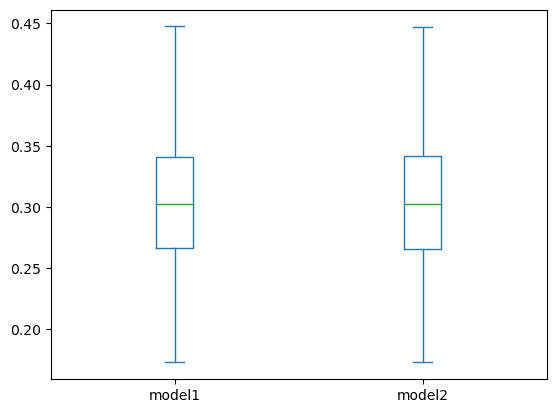

```python
tmp = pd.DataFrame({'model1':res1, 'model2':res2})
t = tmp.describe()
t['delta'] = (t['model2'] - t['model1']).round(4)
print(t)
tmp.plot(kind='box')
```

There are different techniques to iterate over different combination of variables. One of them is the so called stepwise regression.

- Forward stepwise regression: start with the null model and add variables one by one.
- Backward stepwise regression: start with the full model and remove variables one by one.
- Hybrid stepwise regression: a combination of forward and backward stepwise regression.

Besides that, there are other techniques to select variables, for example:

- Regularized regression models (e.g. logit regressions with L1 / L2 penalty called Lasso / Ridge Regressions too)
  - Lasso regression: L1 penalty means that the sum of the absolute values of the coefficients is penalized. This leads to some coefficients being exactly equal to zero. This means that some variables are completely excluded from the model. This is useful for variable selection.
  - Ridge regression: L2 penalty means that the sum of the squared values of the coefficients is penalized. This leads to some coefficients being very small, but not exactly equal to zero. This means that all variables are included in the model, but some variables have a very small effect on the response variable.
- Tree based models like random forests
- ...

Using cross-validation, you can not only select the best combination of variables, but also the "best model".

### Model selection

Using cross-validation, we can not only select the best combination of variables, but also the best model. In our example, we have two different models - both based on a logistic regression framework, but one includes an additional variable. Instead of using a logistic regression, you could also use a different approach, for example:

- random forest classifier,
- gradient boosting classifier,
- XGBoost classifier,
- neural network,
- ...

# Overfitting

Such spurious relationships - relationships that only hold in-sample, but not out-of-sample - are very common in general. Furthermore, some variables may provide some information about the probability of default, but the information content will be too low if other aspects of the variable, which will distort your performance, are taken into account. Think about how many different ratio of balance sheet, P&L and cash flow items you could create.

*But how can you decide if a variable is useful or not, especially with respect the case study?*

1. economic reasoning
2. economic reasoning
3. economic reasoning

Of course, that is not all - you can for example:

- Evaluate each variable of interest alone w.r.t. its prediction power of defaults.
  - Nevertheless, remember that there some variables may not be directly important, but only in combination with another variable.
  - Hence, only looking at p-values and / or a Gini coefficient is not enough, especially in an univariate context.
  - Try to visualize the differences in the distribution of the variables depending on wheather they default or not.
- Identify variables that include nearly the same information - if they include the same information, you will not need both of them - use one or combination (e.g. Dimension Reduction Methods like PCA)
- Use some machine learning techniques, for example:
- Stepwise regressions (Forward, Backward, Hybrid)
- Regularized regressions models (e.g. logit regressions with L1 / L2 penalty called Lasso / Ridge Regressions too)
- Tree based models like random forests

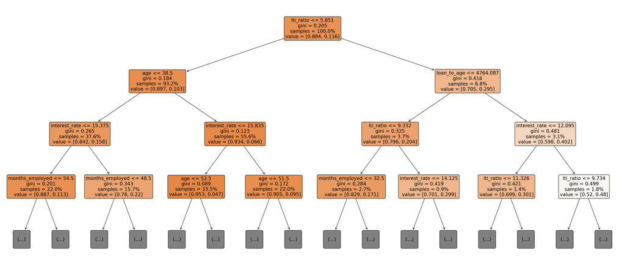

```python
y = df_train.default.astype(int)
cols_x = list(df_train.columns.drop('default'))
X = df_train[cols_x]

mdl = tree.DecisionTreeClassifier(criterion='gini', random_state=100,
                                  max_features=None,
                                  min_samples_split=10,
                                  min_samples_leaf=5, max_depth=20)

mdl.fit(X,y)
p = mdl.predict_proba(X)[:,1]

fig, ax = plt.subplots(figsize=(35, 15))
tree.plot_tree(mdl, max_depth=3, fontsize=15, feature_names=cols_x, proportion=True,
               filled=True, rounded=True)
plt.show()
```

```python
print(tree.export_text(mdl, feature_names=cols_x, spacing=3, decimals=1, show_weights=True))
```

```
|--- lti_ratio <= 5.9
|   |--- age <= 38.5
|   |   |--- interest_rate <= 15.4
|   |   |   |--- months_employed <= 54.5
|   |   |   |   |--- lti_ratio <= 2.6
|   |   |   |   |   |--- interest_rate <= 5.7
|   |   |   |   |   |   |--- age <= 22.5
|   |   |   |   |   |   |   |--- loan_to_term <= 2363.3
|   |   |   |   |   |   |   |   |--- lti_ratio <= 0.1
|   |   |   |   |   |   |   |   |   |--- weights: [3.0, 2.0] class: 0
|   |   |   |   |   |   |   |   |--- lti_ratio >  0.1
|   |   |   |   |   |   |   |   |   |--- months_employed <= 52.5
|   |   |   |   |   |   |   |   |   |   |--- credit_score <= 382.5
|   |   |   |   |   |   |   |   |   |   |   |--- truncated branch of depth 4
|   |   |   |   |   |   |   |   |   |   |--- credit_score >  382.5
|   |   |   |   |   |   |   |   |   |   |   |--- truncated branch of depth 7
|   |   |   |   |   |   |   |   |   |--- months_employed >  52.5
|   |   |   |   |   |   |   |   |   |   |--- interest_rate <= 3.6
|   |   |   |   |   |   |   |   |   |   |   |--- weights: [8.0, 0.0] class: 0
|   |   |   |   |   |   |   |   |   |   |--- interest_rate >  3.6
|   |   |   |   |   |   |   |   |   |   |   |--- weights: [5.0, 4.0] class: 0
|   |   |   |   |   |   |   |--- loan_to_term >  2363.3
|   |   |   |   |   |   |   |   |--- interest_rate <= 4.3
|   |   |   |   |   |   |   |   |   |--- lti_ratio <= 0.5
|   |   |   |   |   |   |   |   |   |   |--- weights: [5.0, 4.0] class: 0
|   |   |   |   |   |   |   |   |   |--- lti_ratio >  0.5
|   |   |   |   |   |   |   |   |   |   |--- loan_to_term <= 9707.5
|   |   |   |   |   |   |   |   |   |   |   |--- truncated branch of depth 8
|   |   |   |   |   |   |   |   |   |   |--- loan_to_term >  9707.5
|   |   |   |   |   |   |   |   |   |   |   |--- truncated branch of depth 5
|   |   |   |   |   |   |   |   |--- interest_rate >  4.3
|   |   |   |   |   |   |   |   |   |--- income <= 98119.5
|   |   |   |   |   |   |   |   |   |   |--- marital_status_divorced <= 0.5
|   |   |   |   |   |   |   |   |   |   |   |--- truncated branch of depth 6
|   |   |   |   |   |   |   |   |   |   |--- marital_status_divorced >  0.5
|   |   |   |   |   |   |   |   |   |   |   |--- truncated branch of depth 4
|   |   |   |   |   |   |   |   |   |--- income >  98119.5
|   |   |   |   |   |   |   |   |   |   |--- credit_score <= 501.5
|   |   |   |   |   |   |   |   |   |   |   |--- truncated branch of depth 5
|   |   |   |   |   |   |   |   |   |   |--- credit_score >  501.5
```

[output cut: 3882 more lines]

```
|   |   |   |   |   |   |   |   |   |   |--- ln_income >  9.8
|   |   |   |   |   |   |   |   |   |   |   |--- weights: [4.0, 3.0] class: 0
|   |   |   |   |   |   |   |   |   |--- dti_ratio >  0.3
|   |   |   |   |   |   |   |   |   |   |--- months_employed <= 40.5
|   |   |   |   |   |   |   |   |   |   |   |--- truncated branch of depth 2
|   |   |   |   |   |   |   |   |   |   |--- months_employed >  40.5
|   |   |   |   |   |   |   |   |   |   |   |--- truncated branch of depth 5
|   |   |   |   |   |   |   |   |--- loan_to_age >  10250.6
|   |   |   |   |   |   |   |   |   |--- income <= 21320.5
|   |   |   |   |   |   |   |   |   |   |--- ln_loan_amount <= 12.3
|   |   |   |   |   |   |   |   |   |   |   |--- weights: [2.0, 3.0] class: 1
|   |   |   |   |   |   |   |   |   |   |--- ln_loan_amount >  12.3
|   |   |   |   |   |   |   |   |   |   |   |--- weights: [0.0, 13.0] class: 1
|   |   |   |   |   |   |   |   |   |--- income >  21320.5
|   |   |   |   |   |   |   |   |   |   |--- weights: [4.0, 2.0] class: 0
```

Feature importance in a tree-based model refers to a numerical measure that describes the contributory worth of each feature in the prediction of the target variable. In tree-based models like Decision Trees, Random Forests, and Gradient Boosting Machines, feature importance is calculated as the total reduction in the model's impurity or error brought by that feature, also known as the Gini importance.

For a decision trees, each node in the tree is a condition on a specific feature, designed to split the dataset into two so that similar response values end up in the same set. The measure of impurity (Gini index, entropy, etc.) depends upon the task being solved (classification, regression, etc.). The importance of a feature is computed as the (normalized) total reduction of the criterion brought by that feature.

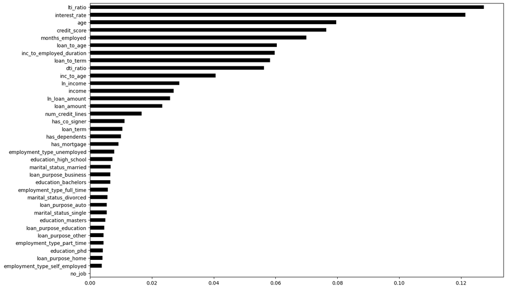

```python
imp = pd.Series(mdl.feature_importances_,index=cols_x).sort_values(ascending=False)
plt.figure(figsize=(15,10))
imp[imp>0].plot.barh(color="black").invert_yaxis();
```

### In sample ROC for Tree

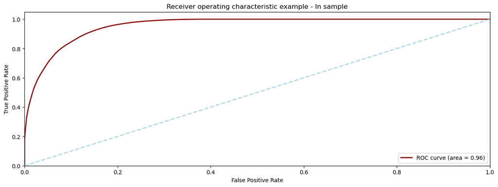

```
AUC:   0.9557647148113855
GINI:  0.911529429622771
```

```python
pdpred = mdl.predict_proba(X)[:,1]

fpr, tpr, thresholds = sk.metrics.roc_curve(df_train.default, pdpred)
auc = metrics.auc(fpr, tpr)

fig, axes = plt.subplots(figsize=(15,5))
lw = 2
axes = plt.plot(fpr, tpr, color='darkred',
                lw=lw, label='ROC curve (area = %0.2f)' % auc)
axes = plt.plot([0, 1], [0, 1], color='lightblue', lw=lw, linestyle='--')
plt.xlim([0.0, 1.0])
plt.ylim([0.0, 1.05])
plt.xlabel('False Positive Rate')
plt.ylabel('True Positive Rate')
plt.title('Receiver operating characteristic example - In sample')
plt.legend(loc="lower right")
plt.show()

print('AUC:  ',auc)
print('GINI: ', 2*auc -1)
```

### Out of sample ROC for Tree

```python
df_test = dataset['test'].copy(deep=True)
variable_types = helpers.get_variable_types(df_test)
df_test = helpers.one_hot_encode_categories(df_test, variables=variable_types['categorical'])
df_test = helpers.compute_additional_variables(df_test)

df_eval = dataset['eval'].copy(deep=True)
```

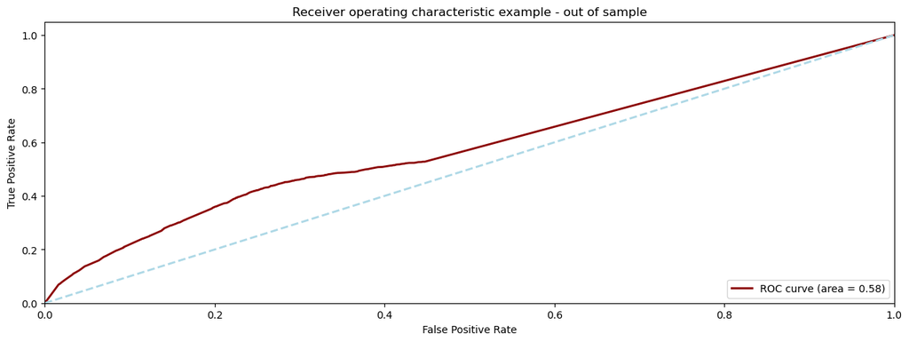

```
AUC:   0.5791780059353607
GINI:  0.15835601187072146
```

```python
X = df_test[cols_x]
pdpred = mdl.predict_proba(X)[:,1]

fpr, tpr, thresholds = sk.metrics.roc_curve(df_eval.default, pdpred)
auc = metrics.auc(fpr, tpr)

fig, axes = plt.subplots(figsize=(15,5))
lw = 2
axes = plt.plot(fpr, tpr, color='darkred',
                lw=lw, label='ROC curve (area = %0.2f)' % auc)
axes = plt.plot([0, 1], [0, 1], color='lightblue', lw=lw, linestyle='--')
plt.xlim([0.0, 1.0])
plt.ylim([0.0, 1.05])
plt.xlabel('False Positive Rate')
plt.ylabel('True Positive Rate')
plt.title('Receiver operating characteristic example - out of sample')
plt.legend(loc="lower right")
plt.show()

print('AUC:  ',auc)
print('GINI: ', 2*auc -1)
```

In contrast, here is the out of sample model performance of model 1 only using the variable age.

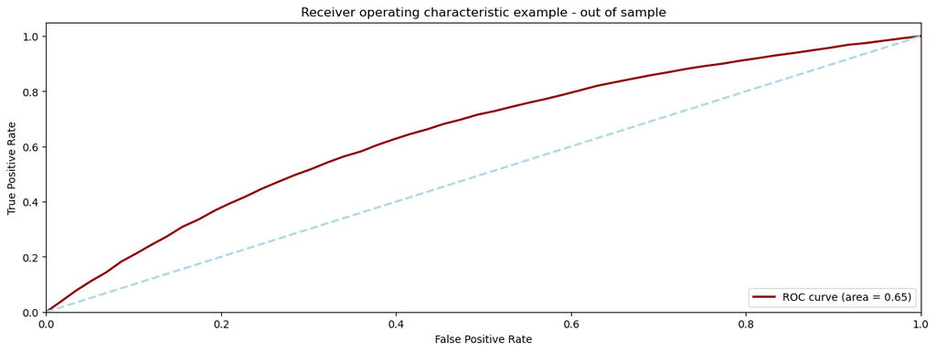

```
AUC:   0.6495660036300495
GINI:  0.2991320072600989
```

```python
X = df_test[cols_x]
pdpred = model1.predict(X)

fpr, tpr, thresholds = sk.metrics.roc_curve(df_eval.default, pdpred)
auc = metrics.auc(fpr, tpr)

fig, axes = plt.subplots(figsize=(15,5))
lw = 2
axes = plt.plot(fpr, tpr, color='darkred',
                lw=lw, label='ROC curve (area = %0.2f)' % auc)
axes = plt.plot([0, 1], [0, 1], color='lightblue', lw=lw, linestyle='--')
plt.xlim([0.0, 1.0])
plt.ylim([0.0, 1.05])
plt.xlabel('False Positive Rate')
plt.ylabel('True Positive Rate')
plt.title('Receiver operating characteristic example - out of sample')
plt.legend(loc="lower right")
plt.show()

print('AUC:  ', auc)
print('GINI: ', 2*auc -1)
```

Logistic regressions aren't without any alternative. There are many interesting candidates you could try out, but I will be very happy with a logistic regressions. Don't forget the story of the case study and don't assume that the people you have to explain your approach, like the CRO, are machine learning experts. A CRO will want to understand what you have done and simply copy some code you found in the world wide web to estimate a fancy super model without understanding it will not be enough. Furthermore, many people in a bank will want to be able to understand the effect of X on Y - and many people have problems to comprehend non-linear relationships. Furthermore, you will prefer a robust model and given the number of observations in your dataset finding a well out-of-sample performing logistic regression model will be difficult enough.

Due to that, I will not go into any details about the below listed methods. Nevertheless, such models are very interesting on their own and if you are able to explain me those models and provide me with an economic reasoning of your results, you are welcome to use them of course.

- Ensambling methods (Boosting and Bagging)
- Generalized Additive Models
- Support Vector and Gradient Boosting Machines
- Random Forests and other tree based models
- Neural networks
- ...